# Crowdflower Search Result Relevance

Jay Teguh Wijaya

Friday, May 15, 2015

## 1. Overview

In this project, I am visualising a dataset of a Kaggle competition called [Search Result Relevance](https://www.kaggle.com/c/crowdflower-search-relevance) by **CrowdFlower**. By choosing this dataset, I am hoping to prove the practicality of doing Udacity courses i.e. have we really learned relevant knowledge to real-world data analysis problem? and what is the gap between what we have learned so far to what the industry needs?

The dataset in this project has initially 6 variables, but we will have to preprocess it so we can use it in our analysis. In the end the dataset used in our analysis would contain 8+ variables, thus adhering to this project’s requirements.

### Helper Document for Reviewers

To help reviewers in reviewing this project, I wrote another document with name “rubric_helper”. In that document I explained the connection between my project and the rubric. Feel free to consult that document while reviewing.

## 2. Competition Description

So many of our favorite daily activities are mediated by proprietary search algorithms. Whether you’re trying to find a stream of that reality TV show on cat herding or shopping an eCommerce site for a new set of Japanese sushi knives, the relevance of search results is often responsible for your (un)happiness. Currently, small online businesses have no good way of evaluating the performance of their search algorithms, making it difficult for them to provide an exceptional customer experience.

The goal of this competition is to create an open-source model that can be used to measure the relevance of search results. In doing so, you’ll be helping enable small business owners to match the experience provided by more resource rich competitors. It will also provide more established businesses a model to test against. Given the queries and resulting product descriptions from leading eCommerce sites, this competition asks you to evaluate the accuracy of their search algorithms.

## 3. About the Dataset

To evaluate search relevancy, CrowdFlower has had their crowd evaluate searches from a handful of eCommerce websites. A total of 261 search terms were generated, and CrowdFlower put together a list of products and their corresponding search terms. Each rater in the crowd was asked to give a product search term a score of 1, 2, 3, 4, with 4 indicating the item completely satisfies the search query, and 1 indicating the item doesn’t match the search term.

The challenge in this competition is to predict the relevance score given the product description and product title. To ensure that your algorithm is robust enough to handle any noisy HTML snippets in the wild real world, the data provided in the product description field is raw and contains information that is irrelevant to the product.

There are two datasets provided for this competition:

1. **train.csv**: Contains training data, which contains target responses.
2. **test.csv**: Contains test data that has no target responses.

In this project, we will only do exploration on training dataset since it contains target responses which are really the point of doing all this analysis.

## 4. Summary Statistics

**Note:** This project does not follow the standard project format **Univariate Plots - Bivariate Plots - Multivariate Plots** but instead it shows the plots before and after preprocessing the data, with several plot types. The reasoning was that it makes more sense narratively.

### 4.1. What is the structure of your dataset?

**Note**: Some of the scripts here are taken from the competition’s official documentation. [^1]

See that `train_raw` has 6 columns:

```
## [1] "id"                  "query"               "product_title"
## [4] "product_description" "median_relevance"    "relevance_variance"
```

with following dimensions:

```
## [1] 10158     6
```

Some explanations of the columns:

- **id**: Product ID
- **query**: Search term used.
- **product_title**: Name of the product.
- **product_description**: The full product description along with HTML formatting tags.
- **median_relevance**: Median relevance score by 3 raters. This value is an integer between 1 and 4. Only available in `train_raw` dataset.
- **relevance_variance**: Variance of the relevance scores given by raters. Only available in `train_raw` dataset.

Number of rows in dataset:

```
## [1] 10158
```

Some of the queries in train set.

```
##  [1] "bridal shower decorations" "led christmas lights"
##  [3] "projector"                 "wine rack"
##  [5] "light bulb"                "oakley polarized radar"
##  [7] "boyfriend jeans"           "screen protector samsung"
##  [9] "pots and pans set"         "waffle maker"
```

The number of unique train queries

```
## [1] 261
```

Now let’s look at the product titles

```
##  [1] "Accent Pillow with Heart Design - Red/Black"
##  [2] "Set of 10 Battery Operated Multi LED Train Christmas Lights - Clear Wire"
##  [3] "ViewSonic Pro8200 DLP Multimedia Projector"
##  [4] "Concept Housewares WR-44526 Solid-Wood Ceiling/Wall-Mount Wine Rack, Charcoal Grey, 6 Bottle"
##  [5] "Wintergreen Lighting Christmas LED Light Bulb (Pack of 25)"
##  [6] "Oakley Sunglasses - Radar Path Polished Black/Gray Sunglasses"
##  [7] "How To Make An American Quilt (DVD)"
##  [8] "ZAGG InvisibleShield Cell Phone Screen Protector for Samsung Galaxy S4 Mini"
##  [9] "Cook N Home Stainless Steel 4-Piece Pasta Cooker/ Steamer Multi-pots with Encapsulated Bottom, 8-Quart"
## [10] "Presto FlipSide Electric Waffle Maker- 03510"
```

The number of unique product titles in the training set

```
## [1] 9708
```

This tells us that we only see most of the product titles once.

### 4.2. What is/are the main feature(s) of interest in your dataset?

We are primarily interested in the feature **Median Relevance** and we wish to find how the search queries correlates to product titles and product descriptions that yield certain values for median relevance.

In order to find this, we will have to create our own feature set that contains: 1. Matching score between query and product title or query and description. 2. Count of title and description.

Some basic statistics of feature median relevance:

```
##    Min. 1st Qu.  Median    Mean 3rd Qu.    Max.
##    1.00    3.00    4.00    3.31    4.00    4.00
```

Most searches have relevance score of 4, followed by 3. Let’s see how many exactly:

```
##
##    1    2    3    4
##  774 1476 1737 6171
```

## 5. initial Explorations

Now let’s start with some basic text analysis on the queries. First, we’ll create a helper function

#### Text Mining Package (tm)

> In this project we use R’s tm package to do all text manipulations.[^2]

```r
# Creating a function plot_word_counts to plot counts of word occurences in different sets
plot_word_counts <- function(documents, title) {
  # Keep only unique documents and convert them to lowercase
  corpus <- Corpus(VectorSource(tolower(unique(documents))))
  # Remove punctuation from the documents
  corpus <- tm_map(corpus, removePunctuation)
  # Remove english stopwords, such as "the" and "a"
  corpus <- tm_map(corpus, removeWords, stopwords("english"))

  doc_terms <- DocumentTermMatrix(corpus)
  doc_terms <- as.data.frame(as.matrix(doc_terms))
  word_counts <- data.frame(Words=colnames(doc_terms),
                            Counts=colSums(doc_terms))
  # Sort from the most frequent words to the least frequent words
  word_counts <- word_counts[order(word_counts$Counts, decreasing=TRUE),]

  top_words <- word_counts[1:10,]
  top_words$Words <- factor(top_words$Words, levels=top_words$Words)

  # Plot the words.
  ggplot(aes(x = Words, y = Counts), data = top_words) +
    geom_bar(stat = "identity", fill = '#4B92E3') +
    scale_y_continuous(
      breaks = seq(0,
                   max(top_words$Counts),
                   ceiling(max(top_words$Counts)/10))) +
    labs(title=title)
}
```

Then we will apply that function to find the most common terms in the query, product title, and product description.

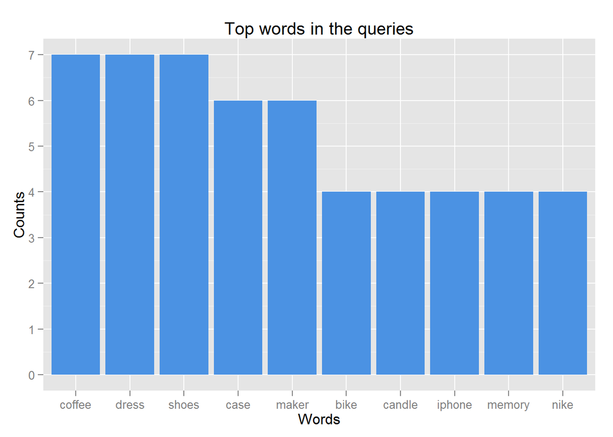

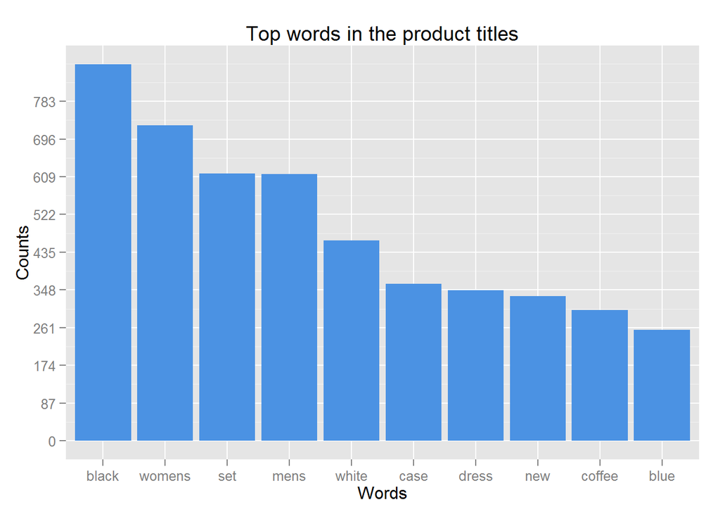

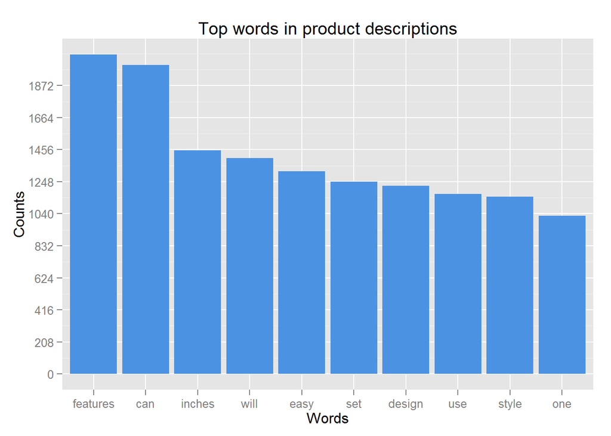

Now that we get a little more understanding on the data, we can begin to wrangle with it to squeeze out useful variables from the dataset.

### 5.1. Setting Up Score Calculation Helpers

With score calculation helper we are basically trying to build a scoring system for query vs. search results that describes a clear correlation between the scores and median relevance (**i.e. the better the score, the higher median relevance should be**).

```r
# This function calculates the score of matches between a list of queries and
# a list of texts. This score simply divides number of found terms in a query with total length of that query. Review how it works from test function test_calculate_match_score.
calculate_match_score <- function(queries, texts) {
  scores <- list(length=length(queries))
  for (i in 1:length(queries)) {
    query <- queries[i]
    text <- texts[i]
    # Remove leading and trailing whitespaces, then split string by whitespaces.
    query_nodes <- unique(strsplit(
      gsub("^\\s+|\\s+$", "", gsub("\\s+", " ", query)), " ")[[1]])
    text_nodes <- unique(strsplit(
      gsub("^\\s+|\\s+$", "", gsub("\\s+", " ", text)), " ")[[1]])
    score <- 0
    for(query_node in query_nodes) {
      score <- score + length(grep(query_node, text_nodes))
    }
    the_score <- score / length(query_nodes)
    if(the_score > 1) {
      the_score <- 1
    }
    scores[[i]] <- (the_score)
  }
  return(as.numeric(scores))
}

# Testing function calculate_match_score
test_calculate_match_score <- function() {
  queries <- c("first query",
               "second query ",
               "third query",
               " this fourth query should",
               "led christma light",
               "soda stream")
  texts <- c(
    "first one should  return 0.5",
    "this one should return 0",
    "this third query   should return 1 third",
    "this fourth one should return 0.75",
    "set  10 batteri oper multi led train christma light  clear wire",
    "sodastream home soda maker kit")
  scores <- calculate_match_score(queries, texts)
  stopifnot(all.equal(scores[[1]], 0.5) &&
            all.equal(scores[[2]], 0) &&
            all.equal(scores[[3]], 1) &&
            all.equal(scores[[4]], 0.75) &&
            all.equal(scores[[5]], 1) &&
            all.equal(scores[[6]], 1))

}
test_calculate_match_score()
train$title_simple_score <- calculate_match_score(train_raw$query, train_raw$product_title)
train$description_simple_score <- calculate_match_score(train_raw$query, train_raw$product_description)
```

Let’s plot simple scoring system to median relevance and relevance variance to see how effective it is.

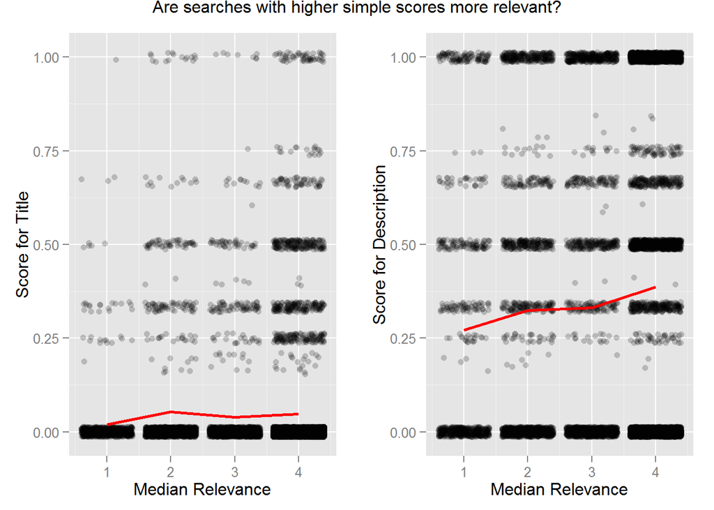

Plotting the score vs relevance with box plots gives us more information on how medians of simple scores progress in each stage of median relevance. These plots also give us insights on which scores are considered outliers.

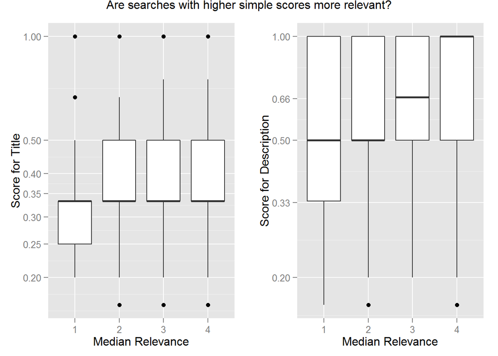

From our initial plot we see that:

As title and description simple scores get larger, so does median relevance. This shows that there is a correlation between more terms in query found within title and description.

Although, it makes little sense that mean of scores from median relevance 2 to 4 gets lower (In other words many people voted that the results are relevant although they see no term they enquired within title and description scores). Let us see if this was caused by the number of rows with 0 matching scores by removing 0 scored rows from our plots:

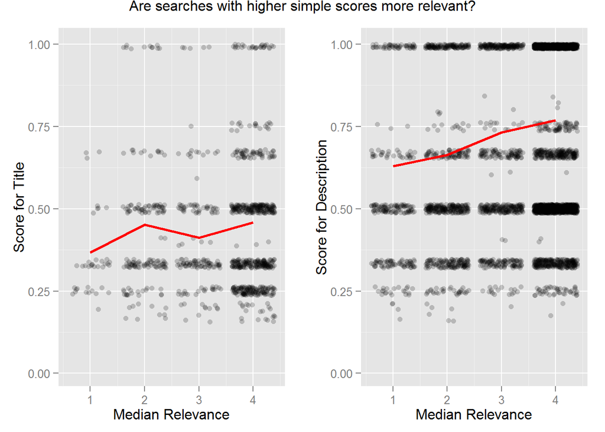

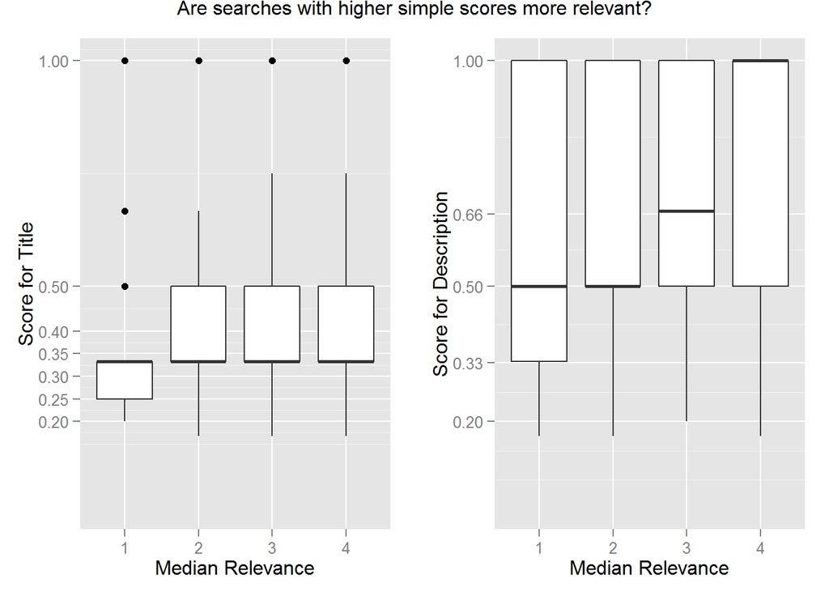

We can see a more visible pattern here, but scoring with title still looks incorrect. Next, let’s see if by using stemmed words we could find a better model (i.e. higher scores result in higher relevancy).

### 5.2. Setting Up Stemming Helpers

#### What is Stemming?

> Stemming is the process of finding the root of a word. For example “running”, “run”, “runs” all derived from the same word “run”. By stemming the words, we are letting our algorithm to be “more lenient” in finding word matches i.e. when you queried for “run”, “Delilah is running” can be considered to contain that word.

Below is our helper to stem passed corpus. In this helper, we also remove punctuations (“.”, “,”, “!”, “?”, etc.) and stop words (“is”, “are”, “does”, etc.).

```r
# `prepare_corpus` is a function to, well, prepare our corpus of words.
# From it we will run our stemming algorithm.
prepare_corpus <- function(df, var) {
  eval(parse(text=paste("corpus <- VCorpus(VectorSource(tolower(",
             "df$", var, ")))", sep="")))
  corpus <- tm_map(corpus, removePunctuation)
  corpus <- tm_map(corpus, removeWords, stopwords("english"))
  corpus <- tm_map(corpus, stripWhitespace)
}

# This function stems the texts found in "var"
stem_corpus <- function(corpus) {
  corpus <- tm_map(corpus, stemDocument)

  corpus_text <- data.frame(
    text=unlist(sapply(corpus, `[`, "content")),
    stringsAsFactors=F
  )
  # "Simple" word count with regex.
  corpus_text$count <- sapply(
    gregexpr("\\b\\W+\\b", corpus_text$text, perl=TRUE),
    function(x) sum(x>0) ) + 1
  return(corpus_text)
}

test_stem_corpus <- function() {
  df <- data.frame(query = c(
    'run',
    'running',
    'runs running',
    'running shoes',
    'ran',
    'I am running'))
  corpus <- prepare_corpus(df, 'query')
  corpus_text <- stem_corpus(corpus)
  stopifnot(
    all.equal(corpus_text$text[1], 'run'),
    all.equal(corpus_text$count[1], 1),
    all.equal(corpus_text$text[2], 'run'),
    all.equal(corpus_text$count[2], 1),
    all.equal(corpus_text$text[3], 'run run'),
    all.equal(corpus_text$count[3], 2),
    all.equal(corpus_text$text[4], 'run shoe'),
    all.equal(corpus_text$count[4], 2),
    all.equal(corpus_text$text[5], 'ran'),
    all.equal(corpus_text$count[5], 1),
    all.equal(corpus_text$text[6], ' run'),
    all.equal(corpus_text$count[6], 1)
  )
}

test_stem_corpus()
```

### 5.3. Preprocessing Dataset

We then preprocess our dataset by doing the following:

- Stem dataset’s queries, product titles, and product descriptions.
- Add word count of stemmed queries, product titles, and product descriptions into variable list of the dataset.
- Do simple score calculation on stemmed queries vs titles and queries vs product descriptions. Add the score into the dataset.

### 5.4. Exploring Our Preprocessed Dataset

Let us now quickly explore the dataset we have just created.

See that our preprocessed dataset `train` has 13 columns:

```
##  [1] "id"
##  [2] "median_relevance"
##  [3] "relevance_variance"
##  [4] "title_simple_score"
##  [5] "description_simple_score"
##  [6] "query_stemmed"
##  [7] "query_stemmed_count"
##  [8] "product_title_stemmed"
##  [9] "product_title_stemmed_count"
## [10] "product_description_stemmed"
## [11] "product_description_stemmed_count"
## [12] "title_stemmed_match_score"
## [13] "description_stemmed_match_score"
```

Some explanations of the new columns:

- **title_simple_score**: Scoring with this simple formula: `score = number of terms in query found in title / total number of terms in that query`. With this formula, *1.00* is the highest score, which means we found all terms in query in title. queries and titles used here are *NOT* stemmed.
- **description_simple_score**: Similar to `title_simple_score` but for `product_description` instead.
- **query_stemmed**: Stemmed queries.
- **query_stemmed_count**: Number of terms found in stemmed queries.
- **product_title_stemmed**: Stemmed product titles.
- **product_title_stemmed_count**: Number of terms found in stemmed product titles.
- **product_description_stemmed**: Stemmed product descriptions.
- **product_description_stemmed_count**: Total number of terms found in stemmed product descriptions.
- **title_stemmed_match_score**: Scores found by comparing stemmed queries and product titles.
- **description_stemmed_match_score**: Scores found by comparing stemmed queries and product descriptions.

Number of rows in dataset:

```
## [1] 10158
```

Let’s look at the queries in the train set now.

```
##  [1] "bridal shower decor"      "led christma light"
##  [3] "projector"                "wine rack"
##  [5] "light bulb"               "oakley polar radar"
##  [7] "boyfriend jean"           "screen protector samsung"
##  [9] "pot pan set"              "waffl maker"
```

```
## [1] 261
```

We see that stemming works properly for our dataset, good.

Summary of the dataset:

```
##       id            median_relevance relevance_variance title_simple_score
##  Length:10158       Min.   :1.00     Min.   :0.0000     Min.   :0.00000
##  Class :character   1st Qu.:3.00     1st Qu.:0.0000     1st Qu.:0.00000
##  Mode  :character   Median :4.00     Median :0.4710     Median :0.00000
##                     Mean   :3.31     Mean   :0.3779     Mean   :0.04443
##                     3rd Qu.:4.00     3rd Qu.:0.4710     3rd Qu.:0.00000
##                     Max.   :4.00     Max.   :1.4700     Max.   :1.00000
##  description_simple_score query_stemmed      query_stemmed_count
##  Min.   :0.0000           Length:10158       Min.   :1.000
##  1st Qu.:0.0000           Class :character   1st Qu.:2.000
##  Median :0.0000           Mode  :character   Median :2.000
##  Mean   :0.3594                              Mean   :2.362
##  3rd Qu.:0.6667                              3rd Qu.:3.000
##  Max.   :1.0000                              Max.   :6.000
##  product_title_stemmed product_title_stemmed_count
##  Length:10158          Min.   : 1.000
##  Class :character      1st Qu.: 6.000
##  Mode  :character      Median : 7.000
##                        Mean   : 7.875
##                        3rd Qu.:10.000
##                        Max.   :38.000
##  product_description_stemmed product_description_stemmed_count
##  Length:10158                Min.   :   1.00
##  Class :character            1st Qu.:   6.00
##  Mode  :character            Median :  30.00
##                              Mean   :  42.63
##                              3rd Qu.:  60.00
##                              Max.   :1343.00
##  title_stemmed_match_score description_stemmed_match_score
##  Min.   :0.0000            Min.   :0.0000
##  1st Qu.:0.5000            1st Qu.:0.0000
##  Median :1.0000            Median :0.6667
##  Mean   :0.7988            Mean   :0.5525
##  3rd Qu.:1.0000            3rd Qu.:1.0000
##  Max.   :1.0000            Max.   :1.0000
```

Now let’s look at the product titles

```
##  [1] "accent pillow heart design redblack"
##  [2] "set 10 batteri oper multi led train christma light clear wire"
##  [3] "viewson pro8200 dlp multimedia projector"
##  [4] "concept housewar wr44526 solidwood ceilingwallmount wine rack charcoal grey 6 bottl"
##  [5] "wintergreen light christma led light bulb pack 25"
##  [6] "oakley sunglass radar path polish blackgray sunglass"
##  [7] " make american quilt dvd"
##  [8] "zagg invisibleshield cell phone screen protector samsung galaxi s4 mini"
##  [9] "cook n home stainless steel 4piec pasta cooker steamer multipot encapsul bottom 8quart"
## [10] "presto flipsid electr waffl maker 03510"
```

```
## [1] 9683
```

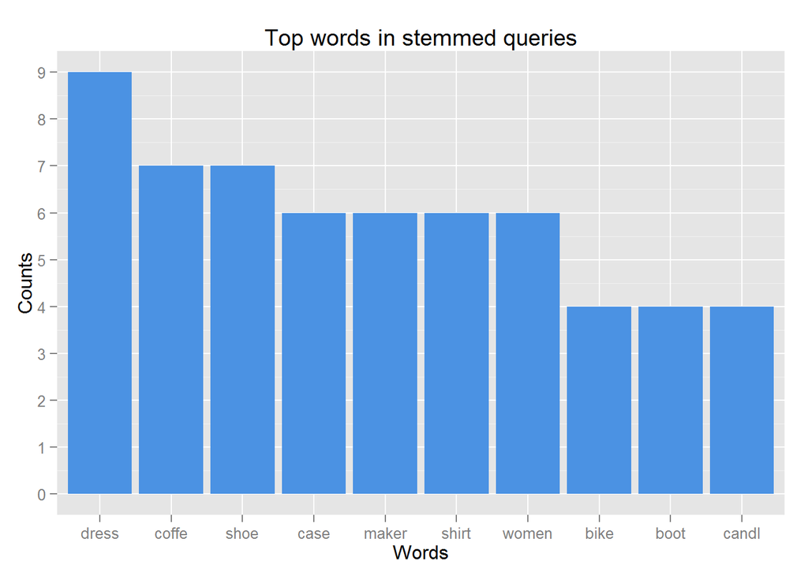

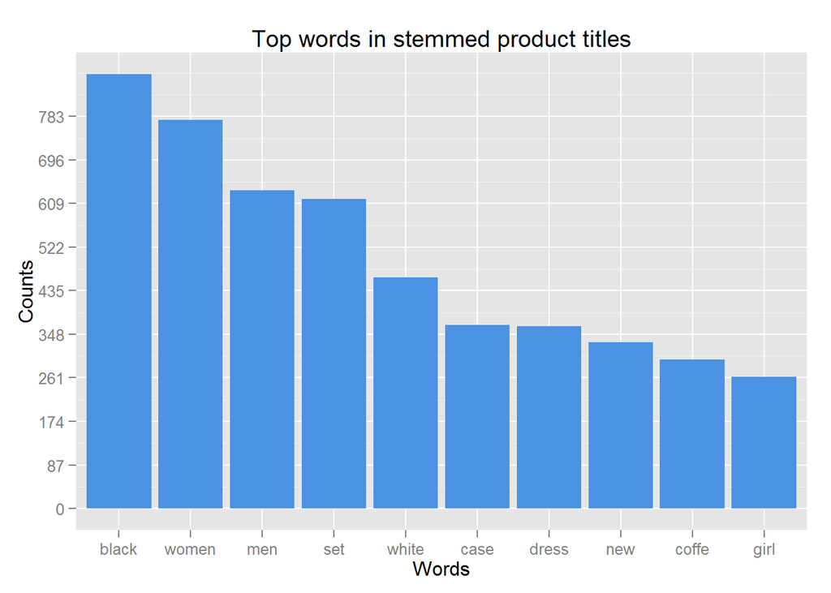

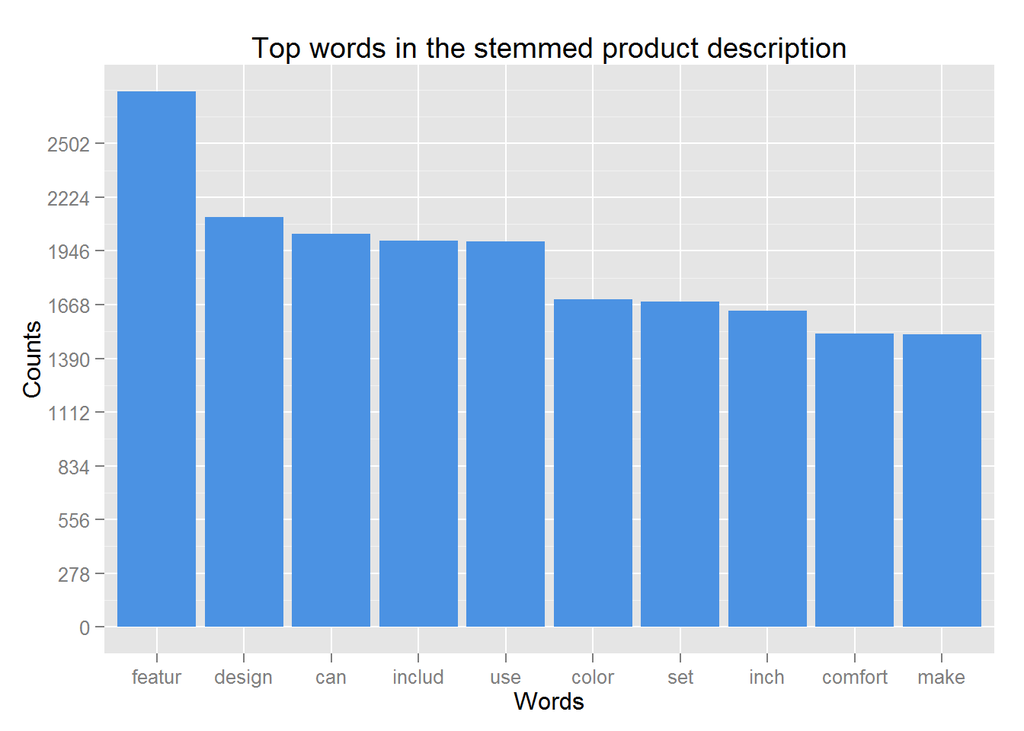

### 5.5. Univariate Plots

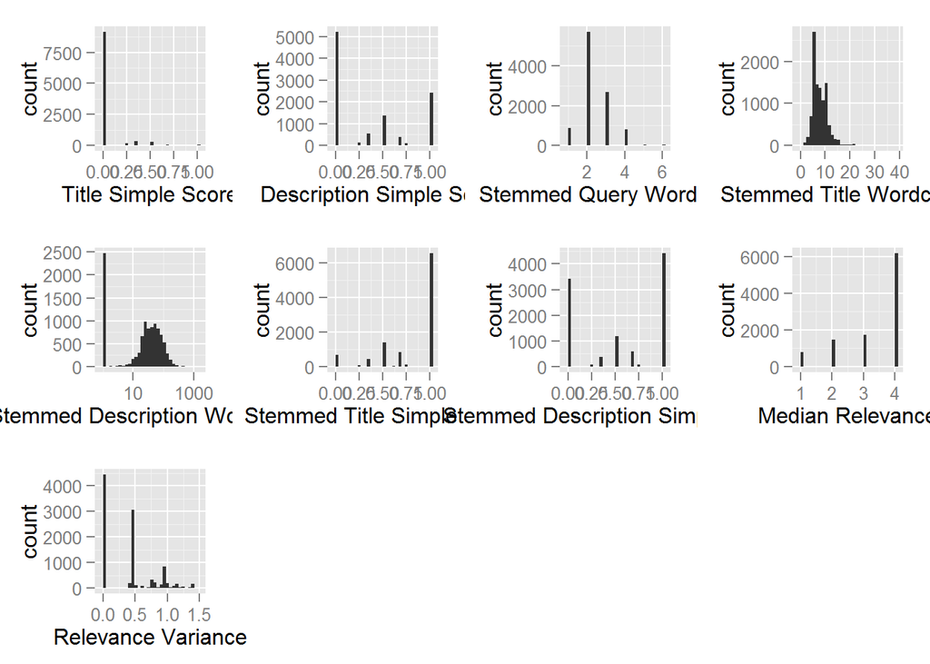

#### Univariate Plots Analysis

- Seems like there are many products without any description.
- Comparing simple scores and stemmed simple scores, it seems stemming increase the scores in general, which is intuitively clear. In one of my final plots I would plot them to compare in more detail.
- Relevance variance is considerably lower at higher values, with median of:

```
## [1] 0.471
```

which means if we later use our model for prediction, there are possibilities that our relevancy prediction is off by that value.

### 5.6. Bivariate Plots

#### Bivariate plots of stemmed variables:

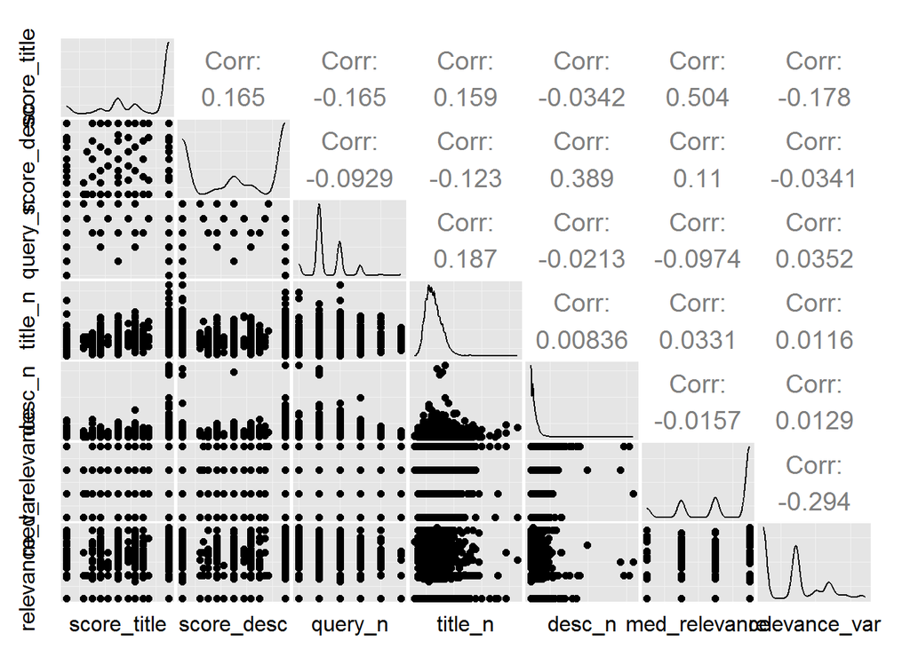

#### Bivariate Plot Analysis

From the above plots, the following can be derived:

- Only stemmed title and description scores have correlation with median relevance of the dataset, with each correlation value of 0.504 and 0.11. We will discuss this further in one of the final plots.
- Relevance variance correlates negatively with median relevance, this means with more relevant searches, there are more people agreeing to the same score.

## 6. Short Questions

### What other features in the dataset do you think will help support your investigation into your feature(s) of interest?

In Google’s early paper about pagerank chapter 3.1. and 3.2., it is explained that searching on the web is vastly different than searching on controlled environment, like text documents, for example. In our dataset, although it seems that users are only looking for a specific product within a single website, that user may compare the result they got with everything else available on the internet instead of that specific product. [^3]

I wonder if we could somehow infer meta information of the products, can we come up with better predictions?

### Did you create any new variables from existing variables in the dataset?

I implemented simple scoring calculation to the dataset, which basically scores how relevant was the search queries to returned product titles and descriptions. These scores are kept in variables **title_simple_score** and **description_simple_score**.

I have also ran a stemming algorithm to dataset queries, titles, and descriptions. They are added to dataset as following variables:

- **query_stemmed**: Contains stemmed query.
- **query_stemmed_count**: Word count in stemmed query.
- **product_title_stemmed**: Contains stemmed product title.
- **product_title_stemmed_count**: Word count in stemmed product title.
- **product_description_stemmed**: Contains stemmed product description.
- **product_description_stemmed_count**: Word count in stemmed product description.

Then I re-ran the scoring calculation using the stemmed terms and kept the results in variables **title_stemmed_match_score** and **description_stemmed_match_score**.

### Of the features you investigated, were there any unusual distributions?Did you perform any operations on the data to tidy, adjust, or change the form of the data? If so, why did you do this?

Initially, the correlation between score of matched queries and median relevance was not apparent. This is quite unusual as common sense would dictate that when more of the words I searched found in result, that should mean the search was accurate / relevant. After some stemming on queries, titles, and descriptions, the pattern starts to show. One of the final plots will explain this further.

## 7. Prediction

Let us try to create a model for predicting future data. This model will use stemmed match scores we have created previously.

```r
suppressWarnings(suppressMessages(library(memisc)))

m1 <- lm(I(median_relevance) ~ I(title_stemmed_match_score), data = train)
m2 <- update(m1, ~ . + description_stemmed_match_score)
mtable(m1, m2)
```

```
##
## Calls:
## m1: lm(formula = I(median_relevance) ~ I(title_stemmed_match_score),
##     data = train)
## m2: lm(formula = I(median_relevance) ~ I(title_stemmed_match_score) +
##     description_stemmed_match_score, data = train)
##
## ======================================================
##                                      m1         m2
## ------------------------------------------------------
## (Intercept)                       2.018***   1.996***
##                                  (0.024)    (0.025)
## I(title_stemmed_match_score)      1.617***   1.602***
##                                  (0.027)    (0.028)
## description_stemmed_match_score              0.062**
##                                             (0.019)
## ------------------------------------------------------
## R-squared                             0.254      0.255
## adj. R-squared                        0.254      0.255
## sigma                                 0.847      0.847
## F                                  3462.386   1737.967
## p                                     0.000      0.000
## Log-likelihood                   -12724.802 -12719.625
## Deviance                           7284.582   7277.160
## AIC                               25455.605  25447.250
## BIC                               25477.283  25476.154
## N                                 10158      10158
## ======================================================
```

```r
# Let's use this data for testing our prediction model:
# query: projector
# title: ViewSonic Pro8200 DLP Multimedia Projector
# description:
# title_stemmed_match_score: 1
# description_stemmed_match_score: 0
# (target) median_relevance: 4

searchResult = data.frame(
  query = "projector",
  title = "ViewSonic Pro8200 DLP Multimedia Projector",
  description = "",
  title_stemmed_match_score = 1,
  description_stemmed_match_score = 0)
modelEstimate = predict(m2, newdata = searchResult,
                        interval="prediction", level = .95)
exp(modelEstimate)
```

```
##        fit      lwr      upr
## 1 36.51751 6.945944 191.9867
```

Alright, seems like lm method only works for continuous targets. Since our problem is those of classification targets, we need to use another method called vglm from VGAM package:[^4]

```r
# load the package
library(VGAM)
# fit model
fit <- vglm(median_relevance ~ I(title_stemmed_match_score) +
            I(description_stemmed_match_score),
            family=multinomial, data=train)
# summarize the fit
summary(fit)
```

```
##
## Call:
## vglm(formula = median_relevance ~ I(title_stemmed_match_score) +
##     I(description_stemmed_match_score), family = multinomial,
##     data = train)
##
## Pearson residuals:
##                       Min      1Q  Median      3Q   Max
## log(mu[,1]/mu[,4]) -2.077 -0.1852 -0.1561 -0.1212 7.774
## log(mu[,2]/mu[,4]) -1.917 -0.3603 -0.3351 -0.2299 3.312
## log(mu[,3]/mu[,4]) -1.632 -0.4407 -0.4381 -0.2687 2.409
##
## Coefficients:
##                                      Estimate Std. Error z value Pr(>|z|)
## (Intercept):1                         1.64597    0.09662  17.035  < 2e-16
## (Intercept):2                         1.29446    0.08799  14.712  < 2e-16
## (Intercept):3                         0.59602    0.09131   6.527 6.69e-11
## I(title_stemmed_match_score):1       -5.12965    0.13507 -37.978  < 2e-16
## I(title_stemmed_match_score):2       -3.34470    0.10415 -32.115  < 2e-16
## I(title_stemmed_match_score):3       -2.21051    0.10290 -21.482  < 2e-16
## I(description_stemmed_match_score):1 -0.35269    0.10624  -3.320 0.000901
## I(description_stemmed_match_score):2 -0.15266    0.07245  -2.107 0.035106
## I(description_stemmed_match_score):3 -0.01241    0.06422  -0.193 0.846766
##
## (Intercept):1                        ***
## (Intercept):2                        ***
## (Intercept):3                        ***
## I(title_stemmed_match_score):1       ***
## I(title_stemmed_match_score):2       ***
## I(title_stemmed_match_score):3       ***
## I(description_stemmed_match_score):1 ***
## I(description_stemmed_match_score):2 *
## I(description_stemmed_match_score):3
## ---
## Signif. codes:  0 '***' 0.001 '**' 0.01 '*' 0.05 '.' 0.1 ' ' 1
##
## Number of linear predictors:  3
##
## Names of linear predictors:
## log(mu[,1]/mu[,4]), log(mu[,2]/mu[,4]), log(mu[,3]/mu[,4])
##
## Dispersion Parameter for multinomial family:   1
##
## Residual deviance: 19479.67 on 30465 degrees of freedom
##
## Log-likelihood: -9739.837 on 30465 degrees of freedom
##
## Number of iterations: 5
```

```r
# make predictions
probabilities <- predict(fit, searchResult, type="response")
# See result
probabilities
```

```
##           1          2         3        4
## 1 0.0225959 0.09474743 0.1464917 0.736165
```

Our model would have predicted median relevance score of 4 with given probability 73.6% which is the correct answer.

## 8. Final Plots and Summary

### 8.1. Plot 1: Was Stemming Useful?

In our first final plot we want to know for sure if stemming the dataset does improve our model.

Let’s plot the score of stemmed matches with their relevance, and compare those with non-stemmed dataset.

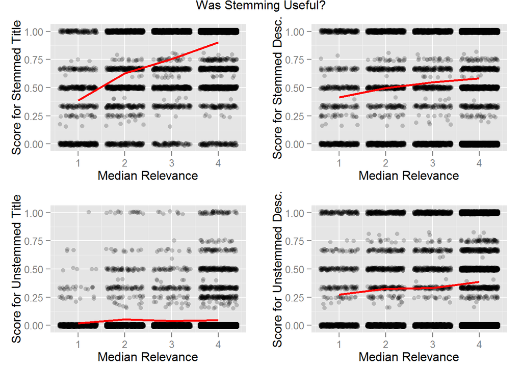

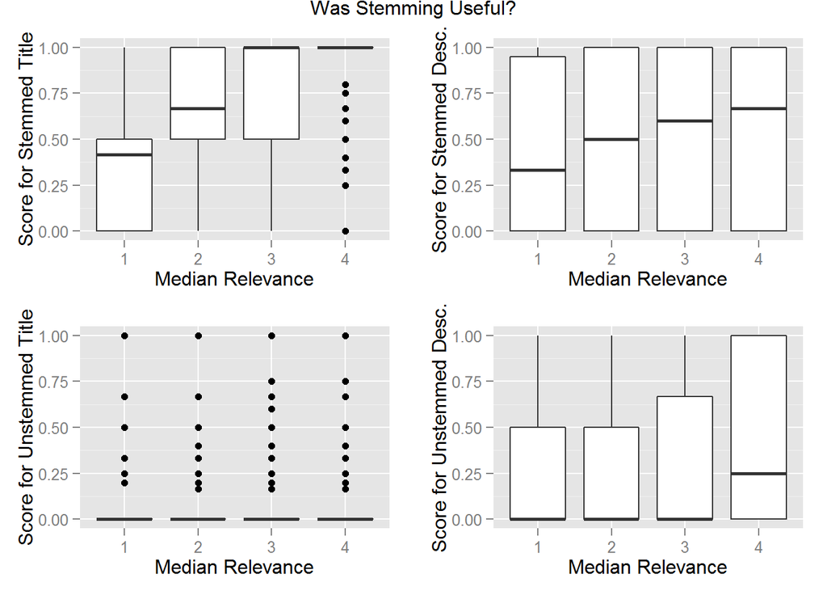

#### Plot 1 Description

Looks like stemming does make our model better:

- The score medians resembles more like a staircase going from low to high value with the stemmed scores, meaning higher scores are considered more relevant from our dataset.
- There are less outliers on stemmed title scoring compared with unstemmed one. This means the pattern is more apparent.
- There is however still seems to be an issue with median relevance of value 4. There are many outliers with the stemmed title scores. This could mean a better scoring algorithm is needed. In **Reflection** section I will explain more on this.

### 8.2. Plot 2: Relationship between Median Relevance and stemmed title and description scores

We have found that the only variables having acceptable correlation (albeit quite low) with median relevance are **stemmed title match score** and **stemmed description match score**.

I wanted to know if, when both stemmed title and description scores are high, does it correlate to higher median relevance?

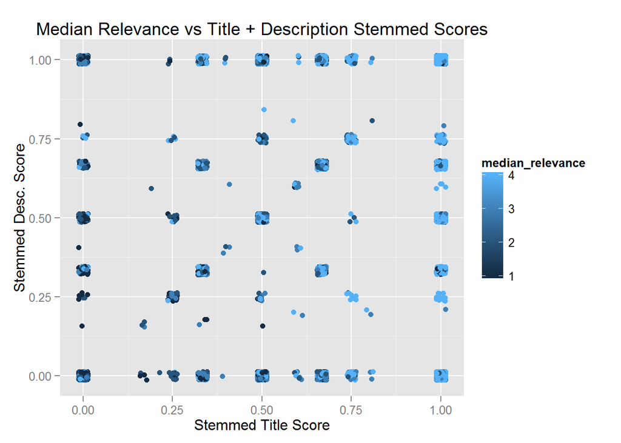

#### Plot 2 Description

One would perceive that results with higher stemmed description and title scores would consistently have higher relevance, but in reality that does not seem to be the case: The colors of nodes with high stemmed title score are lighter in blue despite different values of stemmed description score.

**As it turned out, stemmed description matching with query does not correlate much to search relevancy. Either that, or (more likely) we need to come up with better scoring system for descriptions.**

Additionally, we found that in this dataset there is no direct correlation between stemmed description and stemmed title scores.

### 8.3. Plot 3: Variance of Relevance

Predicting relevance variance might be useful for deciding our confidence level when making prediction of median relevance.

From our previous bivariate plots, we see that relevance variance weakly correlates negatively with median relevance (-0.294) and stemmed title match score (-0.178). Let us plot these variables here to see how they correlate exactly.

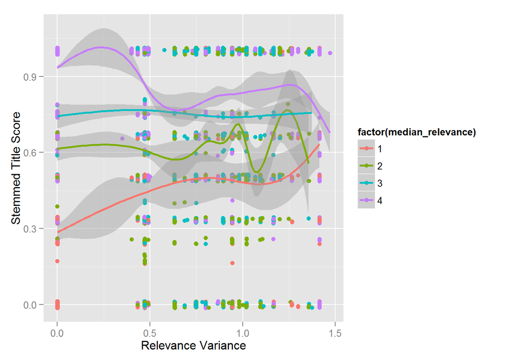

#### Plot 3 Description

This plot fortified our understanding on the connection between relevance variance and score and median relevance. From the plot it is clear that **Higher relevance variance skew the score range for each median relevance.** For example when relevance variance is around 1.25, search queries with stemmed title score of 0.75 could generally be scored as 2 or 3 on its median relevance.

## 9. Reflection

This project has given me much understanding of how to use R in real world case. It was really interesting trying to find correlations between variables and build a prediction based on given training data.

The model I have ended up in this project may not yet be the most optimal model for predicting the data. Additional adjustments to the data and other explorations may be needed. Some ideas I have found among others are:

### 9.1. TF-IDF Scoring

Tf-idf stands for term frequency-inverse document frequency, and the tf-idf weight is a weight often used in information retrieval and text mining. This weight is a statistical measure used to evaluate how important a word is to a document in a collection or corpus. The importance increases proportionally to the number of times a word appears in the document but is offset by the frequency of the word in the corpus. Variations of the tf-idf weighting scheme are often used by search engines as a central tool in scoring and ranking a document’s relevance given a user query.[^5]

It is likely that instead of using a simple scoring system, we are better off using this TF-IDF scoring system.

#### Computing TF-IDF:

**TF:** `TF(t) = (Number of times term t appears in a document) / (Total number of terms in the document)`

**IDF:** `IDF(t) = log_e(Total number of documents / Number of documents with term t in it)`

### 9.2. Lemmatize instead of Stem

**Stemming** usually refers to a crude heuristic process that chops off the ends of words in the hope of achieving this goal correctly most of the time, and often includes the removal of derivational affixes.

**Lemmatization** usually refers to doing things properly with the use of a vocabulary and morphological analysis of words, normally aiming to remove inflectional endings only and to return the base or dictionary form of a word, which is known as the *lemma*.

If confronted with the token *saw*, stemming might return just *s*, whereas lemmatization would attempt to return either *see* or *saw* depending on whether the use of the token was as a *verb* or a *noun*. The two may also differ in that stemming most commonly collapses derivationally related words, whereas lemmatization commonly only collapses the different inflectional forms of a lemma.

Linguistic processing for stemming or lemmatization is often done by an additional plug-in component to the indexing process, and a number of such components exist, both commercial and open-source. [^6]

In our project we have been using stemming to preprocess the terms, but further exploration is required to see if lemmatizing the terms would yield better model.

[^1]: Exploring Crowdflower Data: https://www.kaggle.com/users/993/ben-hamner/crowdflower-search-relevance/exploring-the-crowdflower-data
[^2]: Graham Williams (2014) Hands-On Data Science with R Text Mining http://onepager.togaware.com/TextMiningO.pdf
[^3]: Brin, S. and Page, L. (1998) The Anatomy of a Large-Scale Hypertextual Web Search Engine. http://ilpubs.stanford.edu:8090/361/
[^4]: vlgm method from VGAM package. http://www.inside-r.org/packages/cran/VGAM/docs/vglm
[^5]: TF-IDF - A Single Page Tutorial: http://www.tfidf.com/
[^6]: Stemming and lemmatization. http://nlp.stanford.edu/IR-book/html/htmledition/stemming-and-lemmatization-1.html